# Positive selection in multispecies projects

Emeline Favreau

08/03/2021

Copyright 2021 Emeline Favreau, University College London.

##### Objective of analysis

We obtained the dN/dS value for 1,971 orthogroups shared between 9 species under the null model of all branches being equal (no variation in dN/dS ratios between branches). We then obtained dN/dS values under the alternative model, for which one species is on the foreground branch and all other species on the background (this allows for 2 dN/dS ratios). Because our current analysis is exploratory, this alternative model is applied nine times, one for each species on the foreground branch.

To detect the variation of dn/ds ratio across lineages, we apply log-likelihood tests to compare which model (null or alternative) fits the data best. Then we assess the significance of the result by a test statistics (by calculating a chi-square critical value and a p value).

Our current common gut feeling is that the branch of *Vespa* and *Vespula*, being the most socially complex species, contains the most genes under positive selection.

##### Analysis steps:

- Obtaining data
- make a phylogenetic tree
- Aim 1: calculate number of genes under positive selection
- Aim 2: adjust for multiple comparison and compare

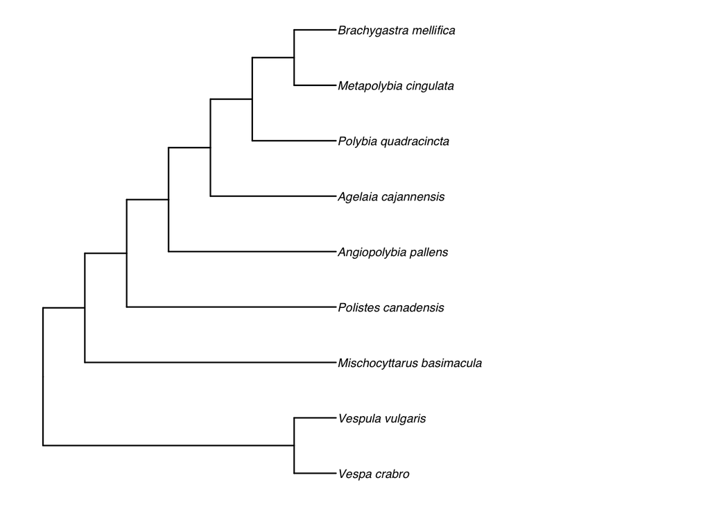

```r
# tidy ttp label
ortho_tree$tip.label <- c("Vespa crabro",
                                  "Vespula vulgaris",
                                  "Mischocyttarus basimacula",
                                  "Polistes canadensis",
                                  "Polybia quadracincta",
                                  "Metapolybia cingulata",
                                  "Brachygastra mellifica",
                                  "Agelaia cajannensis",
                                  "Angiopolybia pallens")



ggtree(ortho_tree,
       branch.length = "none") +
  geom_tiplab(size = 3, aes(fontface = 3)) + xlim(NA, 15)
```

##### Aim 1: Calculate number of genes under positive selection

```
##              species genes under positive selection
## 1            agelaia                              0
## 2       angiopolybia                              1
## 3       brachygastra                              2
## 4        metapolybia                              5
## 5     mischocyttarus                              2
## 6           polistes                              4
## 7            polybia                              2
## 8              vespa                              3
## 9            vespula                              4
## 10 vespa_and_vespula                             23
```

There are a handful for genes for which dN/dS is significantly higher than 1 (not adjusted for multiple comparison).

Here is the list, to be compared with DEGs.

```
## $agelaia
## character(0)
##
## $angiopolybia
## [1] "OG0003803"
##
## $brachygastra
## [1] "OG0002957" "OG0003085"
##
## $metapolybia
## [1] "OG0002796" "OG0003081" "OG0003936" "OG0004039" "OG0004416"
##
## $mischocyttarus
## [1] "OG0003049" "OG0004537"
##
## $polistes
## [1] "OG0003204" "OG0003833" "OG0004604" "OG0005376"
##
## $polybia
## [1] "OG0002942" "OG0005559"
##
## $vespa
## [1] "OG0002988" "OG0003853" "OG0004973"
##
## $vespula
## [1] "OG0003204" "OG0003571" "OG0004251" "OG0005168"
##
## $vespa_and_vespula
##  [1] "OG0003055" "OG0003234" "OG0003281" "OG0003288" "OG0003498" "OG0003532"
##  [7] "OG0004020" "OG0004092" "OG0004165" "OG0004370" "OG0004371" "OG0004390"
## [13] "OG0004674" "OG0004932" "OG0005066" "OG0005128" "OG0005165" "OG0005269"
## [19] "OG0005289" "OG0005384" "OG0005483" "OG0005512" "OG0005595"
```

##### Aim 2: Adjust for multiple comparison and compare

```
##              species genes under positive selection (adj)
## 1            agelaia                                    0
## 2       angiopolybia                                    0
## 3       brachygastra                                    1
## 4        metapolybia                                    0
## 5     mischocyttarus                                    2
## 6           polistes                                    2
## 7            polybia                                    2
## 8              vespa                                    1
## 9            vespula                                    2
## 10 vespa_and_vespula                                   13
```

There are a handful for genes for which dN/dS is significantly higher than 1, when adjusted for multiple comparison (Benjamini and Hochberg).

Here is the list, to be compared with DEGs.

```
## $agelaia
## character(0)
##
## $angiopolybia
## character(0)
##
## $brachygastra
## [1] "OG0002957"
##
## $metapolybia
## character(0)
##
## $mischocyttarus
## [1] "OG0003049" "OG0004537"
##
## $polistes
## [1] "OG0003833" "OG0005376"
##
## $polybia
## [1] "OG0002942" "OG0005559"
##
## $vespa
## [1] "OG0002988"
##
## $vespula
## [1] "OG0003571" "OG0005168"
##
## $vespa_and_vespula
##  [1] "OG0003234" "OG0003281" "OG0003288" "OG0003498" "OG0004020" "OG0004165"
##  [7] "OG0004370" "OG0004371" "OG0004390" "OG0004932" "OG0005128" "OG0005483"
## [13] "OG0005512"
```

Conclusion

These few orthogroups that have experienced positive/relaxed selection, are they part of DEGs?

I think these results need to be used carefully, because the focus was the species branch. This means that while 2 *Vespula* genes experienced positive selection, their orthologous counterparts in the 8 other species did not experienced positive selection (including the other superorganismal *Vespa*).

Allowing *Vespa* and *Vespula* to vary dnds shows that more genes have experienced positive/relaxed selection than the others. This is consistent with current findings (Shell et al 2021) suggesting that eusocial species have more genes under positive selection than species with less complex social organisation.